# Practical ML

Li Lv

Aug.19 2020

## Overview

This project is for Coursera Practical Machine Learning week 4 assignment. The purpose is predict the manner in which they did the excercise based on the collected personal activity. Three methods are attempted, including:

- Random Forest
- Generalized Boosted Model
- Decision Tree

The source large training data set is split to two parts, 70% of them are used for training, and left 30% are used for testing to check the accuracy. The soure testing data set is used for validation.

Based on the invetigation by applying three methods on training and testing data, first two methods have better accuray, with accuracy as 99% and 96% respectively. The Decision Tree has worst result as accuracy 76%.

When three methods are used to do prediction on validation data, it results the first methods get same predition list. With DT method, about 5 items in total 20 records in validation data have different prediction from the previous two methods.

## Load Data and Clean Data

### Load Data

In order to save time, the data set files are downloaded and stored locally.

```r
#urlTrain <- "http://d396qusza40orc.cloudfront.net/predmachlearn/pml-training.csv"
#urtTest <- "http://d396qusza40orc.cloudfront.net/predmachlearn/pml-testing.csv"

#trainFile <- "pml-training.csv"
#testFile <- "pml-testing.csv"
#download.file(urlTrain, trainFile)
#download.file(urlTest, testFile)

trainingData <- read.csv("pml-training.csv")
testingData <- read.csv("pml-testing.csv")

dim(trainingData)
```

```
## [1] 19622   160
```

```r
dim(testingData)
```

```
## [1]  20 160
```

### Create partition with training data set

Large training data set is split to two parts, 70% used for training and 30% used for testing. The source testing data set is used for final validation.

```r
library(caret)
set.seed(112233)
inTrain <- createDataPartition(trainingData$classe, p=0.7, list=FALSE)
trainSet <- trainingData[inTrain, ]
testSet <- trainingData[-inTrain, ]
dim(trainSet)
```

```
## [1] 13737   160
```

```r
dim(testSet)
```

```
## [1] 5885  160
```

### Clean Data

- Remove variance with near zero value

```r
nzvData <- nearZeroVar(trainingData)
trainSet <- trainSet[, -nzvData]
testSet <- testSet[, -nzvData]
dim(trainSet)
```

```
## [1] 13737   100
```

```r
dim(testSet)
```

```
## [1] 5885  100
```

- Remove variance with too many NA

```r
varNA <- apply(trainSet, 2, function(x) mean(is.na(x))) > 0.95
trainSet <- trainSet[, varNA == FALSE]
testSet <- testSet[, varNA == FALSE]

dim(trainSet)
```

```
## [1] 13737    59
```

```r
dim(testSet)
```

```
## [1] 5885   59
```

- Remover unrelevant variants

```r
colnames(trainSet)
```

```
##  [1] "X"                    "user_name"            "raw_timestamp_part_1"
##  [4] "raw_timestamp_part_2" "cvtd_timestamp"       "num_window"
##  [7] "roll_belt"            "pitch_belt"           "yaw_belt"
## [10] "total_accel_belt"     "gyros_belt_x"         "gyros_belt_y"
## [13] "gyros_belt_z"         "accel_belt_x"         "accel_belt_y"
## [16] "accel_belt_z"         "magnet_belt_x"        "magnet_belt_y"
## [19] "magnet_belt_z"        "roll_arm"             "pitch_arm"
## [22] "yaw_arm"              "total_accel_arm"      "gyros_arm_x"
## [25] "gyros_arm_y"          "gyros_arm_z"          "accel_arm_x"
## [28] "accel_arm_y"          "accel_arm_z"          "magnet_arm_x"
## [31] "magnet_arm_y"         "magnet_arm_z"         "roll_dumbbell"
## [34] "pitch_dumbbell"       "yaw_dumbbell"         "total_accel_dumbbell"
## [37] "gyros_dumbbell_x"     "gyros_dumbbell_y"     "gyros_dumbbell_z"
## [40] "accel_dumbbell_x"     "accel_dumbbell_y"     "accel_dumbbell_z"
## [43] "magnet_dumbbell_x"    "magnet_dumbbell_y"    "magnet_dumbbell_z"
## [46] "roll_forearm"         "pitch_forearm"        "yaw_forearm"
## [49] "total_accel_forearm"  "gyros_forearm_x"      "gyros_forearm_y"
## [52] "gyros_forearm_z"      "accel_forearm_x"      "accel_forearm_y"
## [55] "accel_forearm_z"      "magnet_forearm_x"     "magnet_forearm_y"
## [58] "magnet_forearm_z"     "classe"
```

It looks the first 6 variants about idenity and timestamp are not relevant to the measurement. [1] "X" "user_name" "raw_timestamp_part_1" [4] "raw_timestamp_part_2" "cvtd_timestamp" "num_window"

The first 6 variants are removed.

```r
trainSet <- trainSet[, -(1:6)]
testSet <- testSet[, -(1:6)]
dim(trainSet)
```

```
## [1] 13737    53
```

```r
dim(testSet)
```

```
## [1] 5885   53
```

```r
colnames(trainSet)
```

```
##  [1] "roll_belt"            "pitch_belt"           "yaw_belt"
##  [4] "total_accel_belt"     "gyros_belt_x"         "gyros_belt_y"
##  [7] "gyros_belt_z"         "accel_belt_x"         "accel_belt_y"
## [10] "accel_belt_z"         "magnet_belt_x"        "magnet_belt_y"
## [13] "magnet_belt_z"        "roll_arm"             "pitch_arm"
## [16] "yaw_arm"              "total_accel_arm"      "gyros_arm_x"
## [19] "gyros_arm_y"          "gyros_arm_z"          "accel_arm_x"
## [22] "accel_arm_y"          "accel_arm_z"          "magnet_arm_x"
## [25] "magnet_arm_y"         "magnet_arm_z"         "roll_dumbbell"
## [28] "pitch_dumbbell"       "yaw_dumbbell"         "total_accel_dumbbell"
## [31] "gyros_dumbbell_x"     "gyros_dumbbell_y"     "gyros_dumbbell_z"
## [34] "accel_dumbbell_x"     "accel_dumbbell_y"     "accel_dumbbell_z"
## [37] "magnet_dumbbell_x"    "magnet_dumbbell_y"    "magnet_dumbbell_z"
## [40] "roll_forearm"         "pitch_forearm"        "yaw_forearm"
## [43] "total_accel_forearm"  "gyros_forearm_x"      "gyros_forearm_y"
## [46] "gyros_forearm_z"      "accel_forearm_x"      "accel_forearm_y"
## [49] "accel_forearm_z"      "magnet_forearm_x"     "magnet_forearm_y"
## [52] "magnet_forearm_z"     "classe"
```

## Model Building

Three model types are attempted to find out the one with better out-of-sample accuracy.

- Random Forest
- Generallized Boosted model
- Decision Tree

### Random Forest

Model Fit: Since it is slow to run train on big data set, so the model fit result is recorded in one file.

```r
set.seed(112345)
#conRF <- trainControl(method="cv", number=3, verboseIter = FALSE)
#modRF <- train(classe ~ ., data=trainSet, method="rf", trControl = conRF)
#save(modRF, file='./ModelRF.RData')
load("ModelRF.RData")
#modRF$finalModel
```

Predict on testing data:

```r
preRF <- predict(modRF, newdata=testSet)
testSet$classe <- as.factor(testSet$classe)
confRF <- confusionMatrix(preRF, testSet$classe)
confRF
```

```
## Confusion Matrix and Statistics
##
##           Reference
## Prediction    A    B    C    D    E
##          A 1672    9    0    0    0
##          B    0 1126    4    0    0
##          C    2    3 1017    9    1
##          D    0    1    5  955    5
##          E    0    0    0    0 1076
##
## Overall Statistics
##
##                Accuracy : 0.9934
##                  95% CI : (0.991, 0.9953)
##     No Information Rate : 0.2845
##     P-Value [Acc > NIR] : < 2.2e-16
##
##                   Kappa : 0.9916
##
##  Mcnemar's Test P-Value : NA
##
## Statistics by Class:
##
##                      Class: A Class: B Class: C Class: D Class: E
## Sensitivity            0.9988   0.9886   0.9912   0.9907   0.9945
## Specificity            0.9979   0.9992   0.9969   0.9978   1.0000
## Pos Pred Value         0.9946   0.9965   0.9855   0.9886   1.0000
## Neg Pred Value         0.9995   0.9973   0.9981   0.9982   0.9988
## Prevalence             0.2845   0.1935   0.1743   0.1638   0.1839
## Detection Rate         0.2841   0.1913   0.1728   0.1623   0.1828
## Detection Prevalence   0.2856   0.1920   0.1754   0.1641   0.1828
## Balanced Accuracy      0.9983   0.9939   0.9941   0.9942   0.9972
```

Plot the result:

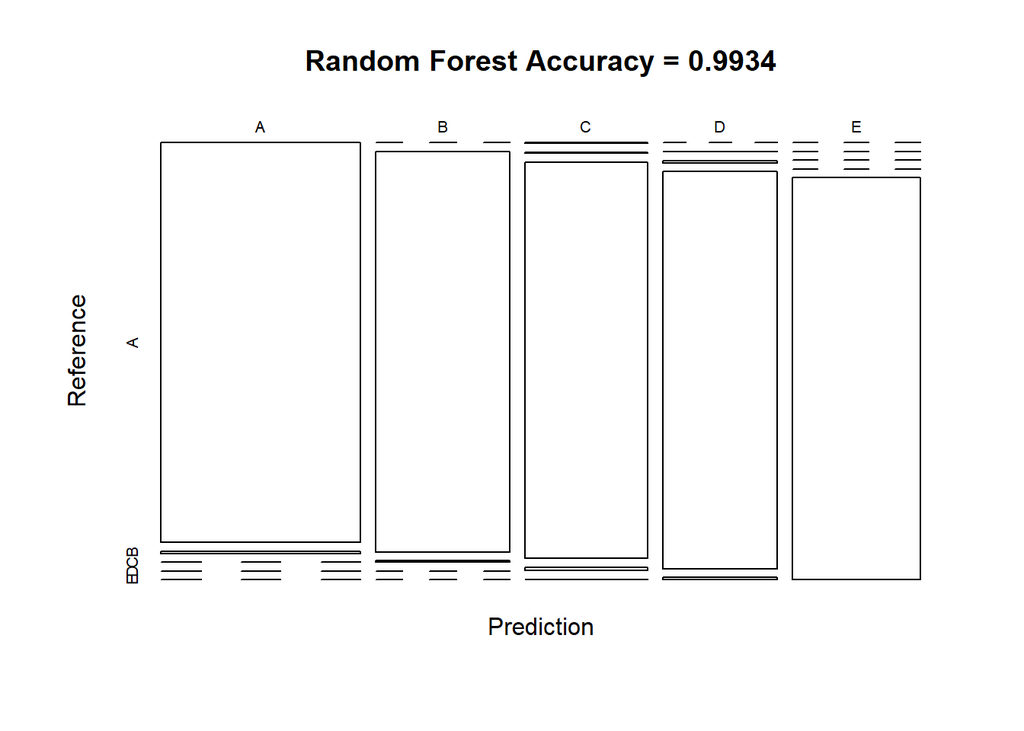

```r
plot(confRF$table, col=confRF$byClass,
     main=paste("Random Forest Accuracy =",
                round(confRF$overall['Accuracy'],4)))
```

### Decision Tree

Decision Tree modle fit:

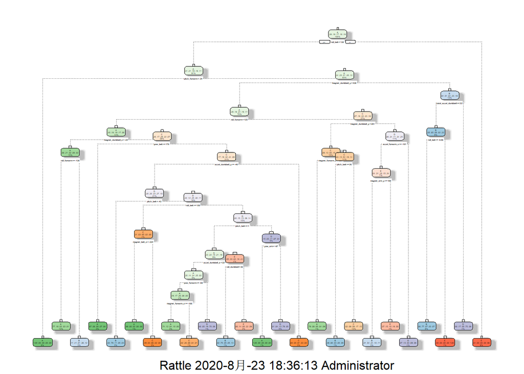

```r
library(rpart)
library(rpart.plot)
library(rattle)
set.seed(212345)
modDT <- rpart(classe ~ ., data=trainSet, method="class")
save(modDT, file='./ModelDT.RData')

fancyRpartPlot(modDT)
```

Predict Decision Tree result on testing data:

```r
preDT <- predict(modDT, newdata=testSet, type="class")
confDT <- confusionMatrix(preDT, testSet$classe)
confDT
```

```
## Confusion Matrix and Statistics
##
##           Reference
## Prediction    A    B    C    D    E
##          A 1506  164   24   50   10
##          B   51  741   91   81  119
##          C   54  118  827  138  116
##          D   14   65   57  600   45
##          E   49   51   27   95  792
##
## Overall Statistics
##
##                Accuracy : 0.7589
##                  95% CI : (0.7477, 0.7698)
##     No Information Rate : 0.2845
##     P-Value [Acc > NIR] : < 2.2e-16
##
##                   Kappa : 0.6944
##
##  Mcnemar's Test P-Value : < 2.2e-16
##
## Statistics by Class:
##
##                      Class: A Class: B Class: C Class: D Class: E
## Sensitivity            0.8996   0.6506   0.8060   0.6224   0.7320
## Specificity            0.9411   0.9279   0.9123   0.9632   0.9538
## Pos Pred Value         0.8586   0.6842   0.6600   0.7682   0.7811
## Neg Pred Value         0.9593   0.9171   0.9570   0.9287   0.9405
## Prevalence             0.2845   0.1935   0.1743   0.1638   0.1839
## Detection Rate         0.2559   0.1259   0.1405   0.1020   0.1346
## Detection Prevalence   0.2980   0.1840   0.2129   0.1327   0.1723
## Balanced Accuracy      0.9204   0.7893   0.8592   0.7928   0.8429
```

Plot confusion matrix result:

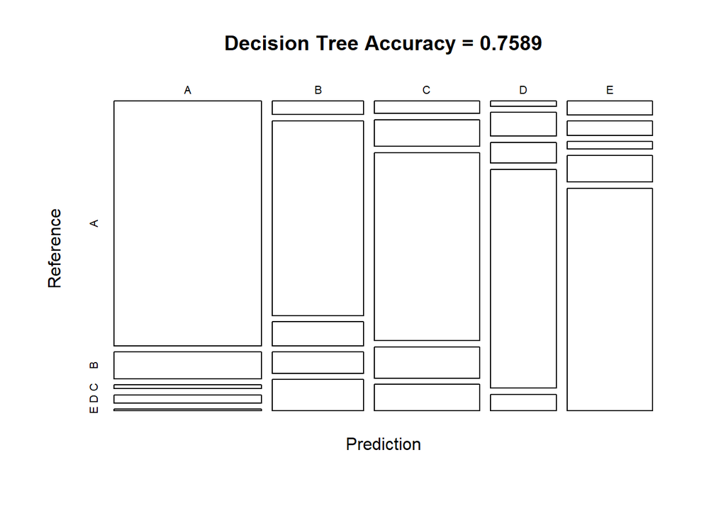

```r
plot(confDT$table, col=confDT$byClass,
     main=paste("Decision Tree Accuracy =",
                round(confDT$overall['Accuracy'],4)))
```

### Generalized Boosted Model

GBM modle fit: Since it is slow to run train on big data set, so the model fit result is recorded in one file.

```r
set.seed(312345)
#conGBM <- trainControl(method="repeatedcv", number=5, repeats=1)
#modGBM <- train(classe ~ ., data=trainSet, method="gbm",
#                trControl = conGBM, verbose=FALSE)
#save(modGBM, file='./ModelGBM.RData')
load("ModelGBM.RData")
#modGBM$finalModel
```

Predict on testing data:

```r
preGBM <- predict(modGBM, newdata=testSet)
confGBM <- confusionMatrix(preGBM, testSet$classe)
confGBM
```

```
## Confusion Matrix and Statistics
##
##           Reference
## Prediction    A    B    C    D    E
##          A 1643   36    0    2    3
##          B   11 1072   27    8   11
##          C   16   29  990   32    9
##          D    2    1    8  918    8
##          E    2    1    1    4 1051
##
## Overall Statistics
##
##                Accuracy : 0.9641
##                  95% CI : (0.9591, 0.9687)
##     No Information Rate : 0.2845
##     P-Value [Acc > NIR] : < 2.2e-16
##
##                   Kappa : 0.9546
##
##  Mcnemar's Test P-Value : 3.28e-10
##
## Statistics by Class:
##
##                      Class: A Class: B Class: C Class: D Class: E
## Sensitivity            0.9815   0.9412   0.9649   0.9523   0.9713
## Specificity            0.9903   0.9880   0.9823   0.9961   0.9983
## Pos Pred Value         0.9757   0.9495   0.9201   0.9797   0.9924
## Neg Pred Value         0.9926   0.9859   0.9925   0.9907   0.9936
## Prevalence             0.2845   0.1935   0.1743   0.1638   0.1839
## Detection Rate         0.2792   0.1822   0.1682   0.1560   0.1786
## Detection Prevalence   0.2862   0.1918   0.1828   0.1592   0.1799
## Balanced Accuracy      0.9859   0.9646   0.9736   0.9742   0.9848
```

Plot confusion matrix result:

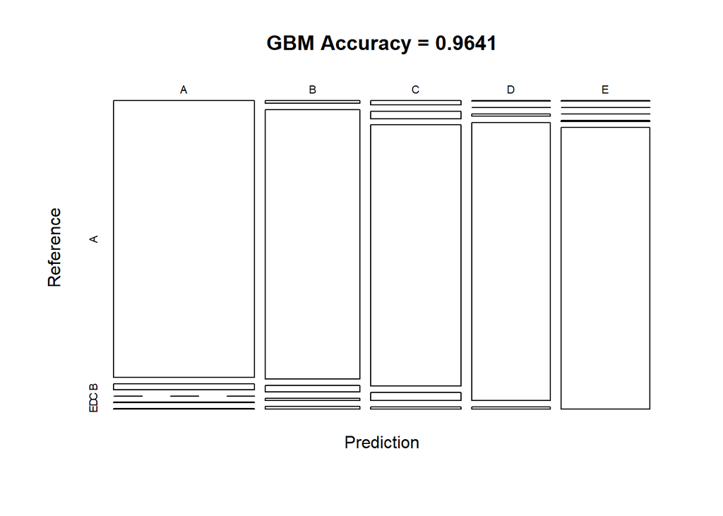

```r
plot(confGBM$table, col=confGBM$byClass,
     main=paste("GBM Accuracy =",
                round(confGBM$overall['Accuracy'],4)))
```

### Summary of diffent method

Based on previous investigation result, Random Forest has best accuracy on testing data with accuracy 99%. The Generalized Boosted Model has acuracy as 96%. The Decision Tree has worst result as 76%.

## Prediction on validation data

Three methods are attempted to apply on the validation data, it shows the RF and GBM result in same prediction. 5 items of total 20 records from DT method result are different from previous two methods.

```r
preRFVal <- predict(modRF, newdata=testingData)
preGBMVal <- predict(modGBM, newdata=testingData)
preDTVal <- predict(modDT, newdata=testingData)

preDTVal <- apply(preDTVal, 1, function(x) colnames(preDTVal)[which.max(x)])

valResult <- data.frame(problem_id=testingData$problem_id,
                        predbyRF=preRFVal,
                        predbyGBM=preGBMVal,
                        GBMvsRF = (preRFVal==preGBMVal),
                        predbyDT=preDTVal,
                        DTvsRF = (preRFVal==preDTVal))
valResult
```

```
##    problem_id predbyRF predbyGBM GBMvsRF predbyDT DTvsRF
## 1           1        B         B    TRUE        B   TRUE
## 2           2        A         A    TRUE        A   TRUE
## 3           3        B         B    TRUE        B   TRUE
## 4           4        A         A    TRUE        A   TRUE
## 5           5        A         A    TRUE        A   TRUE
## 6           6        E         E    TRUE        C  FALSE
## 7           7        D         D    TRUE        D   TRUE
## 8           8        B         B    TRUE        D  FALSE
## 9           9        A         A    TRUE        A   TRUE
## 10         10        A         A    TRUE        A   TRUE
## 11         11        B         B    TRUE        C  FALSE
## 12         12        C         C    TRUE        B  FALSE
## 13         13        B         B    TRUE        C  FALSE
## 14         14        A         A    TRUE        A   TRUE
## 15         15        E         E    TRUE        E   TRUE
## 16         16        E         E    TRUE        E   TRUE
## 17         17        A         A    TRUE        A   TRUE
## 18         18        B         B    TRUE        B   TRUE
## 19         19        B         B    TRUE        B   TRUE
## 20         20        B         B    TRUE        B   TRUE
```